# Lab 8: Sequence Alignment, Phylogenetic Analysis and Tree Visualization

#### Overlay organism silouhettes

phylopic.org (http://phylopic.org/) hosts free silhouette images of animals, plants, and other life forms, all under Creative Commons or Public Domain. You can use ggtree to overlay a phylopic image on your plot at a node of your choosing.

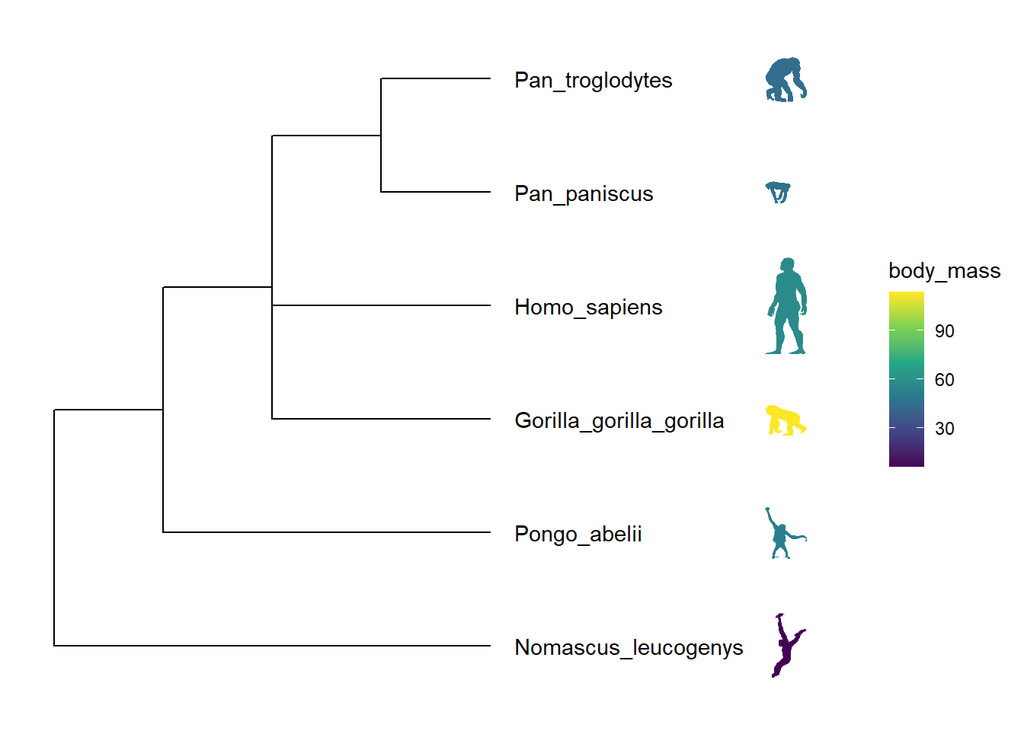

```r
# get phylopic

newick <- "((Pongo_abelii,(Gorilla_gorilla_gorilla,(Pan_paniscus,Pan_troglodytes)Pan,Homo_sapiens)Homininae)Hominidae,Nomascus_leucogenys)Hominoidea;"

tree <- read.tree(text=newick)

d <- ggimage::phylopic_uid(tree$tip.label)
d$body_mass = c(52, 114, 47, 45, 58, 6)

p <- ggtree(tree) %<+% d +
  geom_tiplab(aes(image=uid, colour=body_mass), geom="phylopic", offset=2.5) +
  geom_tiplab(aes(label=label), offset = .2) + xlim(NA, 7) +
  scale_color_viridis_c()
p
```

4. Upload your tree file from the FastTreeMP output on CIPRES into R using treeio. Using ggtree to make the tree images, coloring the tree according to the domains of life.

```r
tree <- read.tree("data/TOL_fastree_result.tre")
tree
```

```
##
## Phylogenetic tree with 21 tips and 19 internal nodes.
##
## Tip labels:
##   Archaeoglobus_fulgidus, Trypanosoma_cruzi, Amphidinium_carterae, Saccharomyces_cerevisiae, Homo_sapies, Drosophila_yakuba, ...
## Node labels:
##   , 0.999, 0.874, 1.000, 0.985, 0.984, ...
##
## Unrooted; includes branch lengths.
```

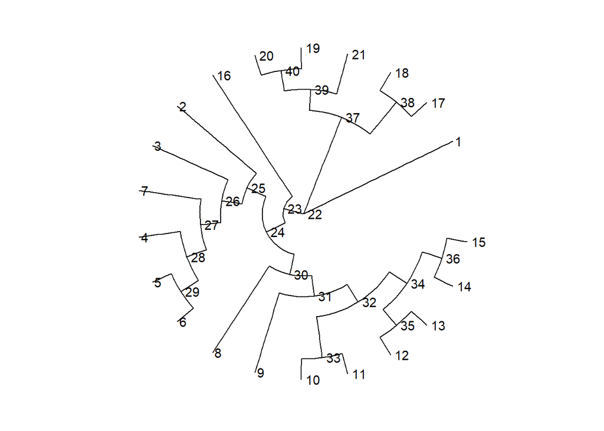

```r
ggtree(tree, branch.length="none",layout="circular") + geom_text(aes(label=node), hjust=-.3)
```

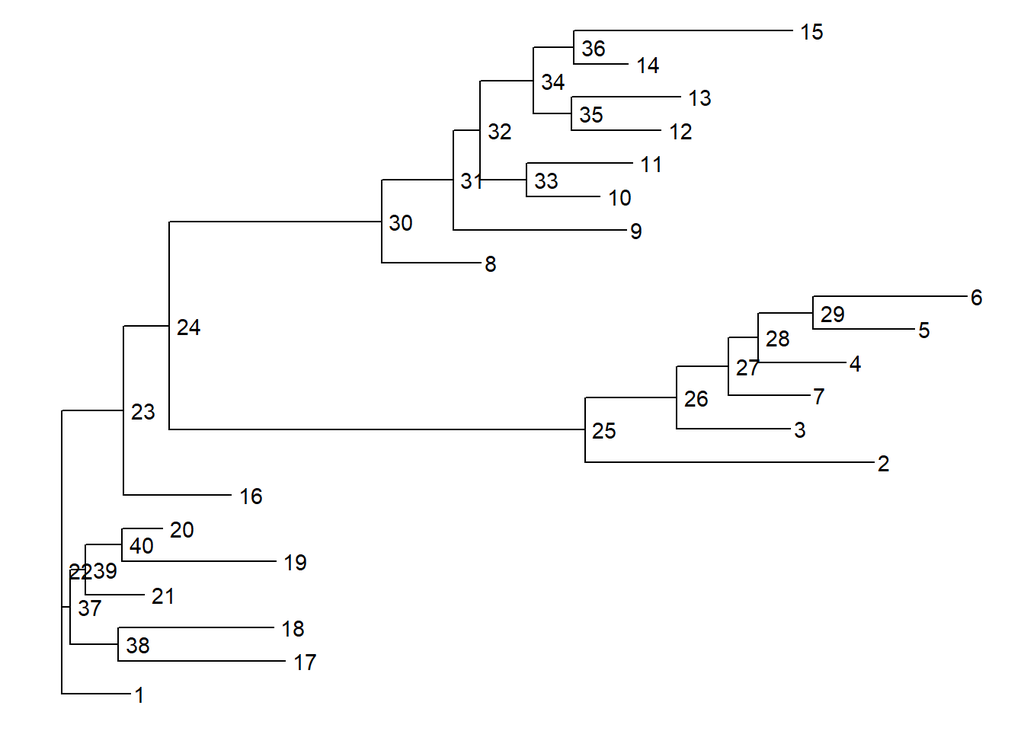

```r
ggtree(tree) + geom_text(aes(label=node), hjust=-.3)
```

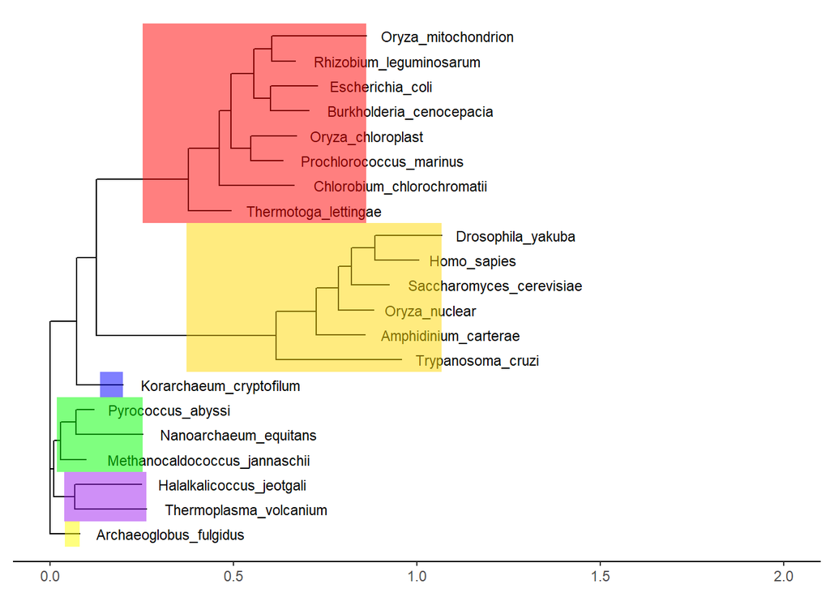

```r
ggtree(tree)  +
  theme_tree2() +
  geom_tiplab(hjust=-.1, size = 3) +
  geom_hilight(node=30, fill="red") +
  geom_hilight(node=25, fill="gold") +
  geom_hilight(node=16, fill="blue") +
  geom_hilight(node=39, fill="green") +
  geom_hilight(node=38, fill="purple") +
  geom_hilight(node=1, fill="yellow") +
  xlim(0,2)
```

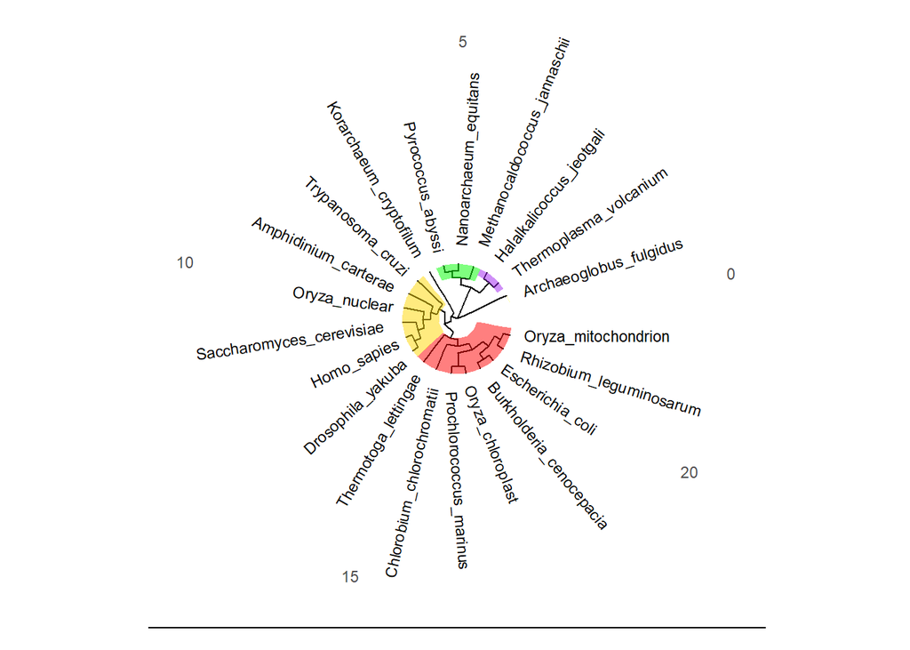

```r
ggtree(tree, branch.length="none", layout="circular")  +
  theme_tree2() +
  geom_tiplab(hjust=-.1, size = 3) +
  geom_hilight(node=30, fill="red") +
  geom_hilight(node=25, fill="gold") +
  geom_hilight(node=16, fill="blue") +
  geom_hilight(node=39, fill="green") +
  geom_hilight(node=38, fill="purple") +
  geom_hilight(node=1, fill="yellow") +
  xlim(0, 36)
```

If you the tree is not fitting in the plot space you can modify the xlim

```r
# Add to your
#ggtree(tree) +
  #xlim(0,2) # This worked from my rectangular trees
  #xlim(0.36) # This worked for my circular trees
```

To show the bootstrap values

```r
#ggtree(tree) +
#  geom_nodelab()
```

To change text size and position

```r
#ggtree(tree) +
#  geom_tiplab(hjust=-.1, size = 3)
```

To change the size of the highlighted clade you can use extend

```r
#ggtree(tree) +
#  geom_hilight(node=34, fill="gold", extend = 0.5)
```